# Visualizacion Estática

Este notebook es para la creación del gráfico estatico de banderas. Primero se cargan las librerias:

```python
import pandas as pd
pd.set_option('display.max_columns', 500)
%matplotlib inline
import matplotlib.pyplot as plt
plt.style.use('ggplot')
import seaborn as sns
import requests
from PIL import Image
from io import BytesIO
```

Ahora se carga el df que esta guardado en flags.pkl que fue generado con generate_data.ipynb

```python
df_flags = pd.read_pickle("flags.pkl")
display(df_flags.sort_values(by="sum_unique", ascending=False).head())
```

|  | color | AD | AE | AF | AG | AI | AL | AM | AO | AQ | AR | AS | AT | AU | AW | AX | AZ | BA | BB | BD | BE | BF | BG | BH | BI | BJ | BL | BM | BN | … |
| --- | --- | --- | --- | --- | --- | --- | --- | --- | --- | --- | --- | --- | --- | --- | --- | --- | --- | --- | --- | --- | --- | --- | --- | --- | --- | --- | --- | --- | --- | --- |
| 22 | white | 0.0 | 572.0 | 0.0 | 146.0 | 211.0 | 0.0 | 0.0 | 0.0 | 676.0 | 716.0 | 113.0 | 780.0 | 158.0 | 0.0 | 0.0 | 18.0 | 28.0 | 0.0 | 0.0 | 0.0 | 0.0 | 780.0 | 726.0 | 790.0 | 0.0 | 1221.0 | 172.0 | 380.0 | … |
| 2 | crimson | 802.0 | 640.0 | 10.0 | 1158.0 | 12.0 | 1885.0 | 0.0 | 1112.0 | 0.0 | 0.0 | 34.0 | 1620.0 | 12.0 | 15.0 | 384.0 | 766.0 | 0.0 | 0.0 | 498.0 | 800.0 | 1136.0 | 0.0 | 1600.0 | 627.0 | 720.0 | 15.0 | 12.0 | 36.0 | … |
| 8 | gold | 524.0 | 0.0 | 0.0 | 86.0 | 0.0 | 0.0 | 0.0 | 41.0 | 0.0 | 0.0 | 0.0 | 0.0 | 0.0 | 360.0 | 672.0 | 0.0 | 780.0 | 666.0 | 0.0 | 800.0 | 78.0 | 0.0 | 0.0 | 0.0 | 720.0 | 6.0 | 0.0 | 1195.0 | … |
| 7 | firebrick | 2.0 | 0.0 | 597.0 | 18.0 | 36.0 | 100.0 | 0.0 | 28.0 | 0.0 | 0.0 | 222.0 | 0.0 | 36.0 | 0.0 | 0.0 | 0.0 | 0.0 | 0.0 | 0.0 | 0.0 | 0.0 | 840.0 | 0.0 | 8.0 | 0.0 | 33.0 | 49.0 | 86.0 | … |
| 9 | goldenrod | 60.0 | 0.0 | 0.0 | 24.0 | 0.0 | 0.0 | 0.0 | 29.0 | 0.0 | 2.0 | 14.0 | 0.0 | 0.0 | 0.0 | 0.0 | 0.0 | 0.0 | 12.0 | 0.0 | 0.0 | 6.0 | 0.0 | 0.0 | 0.0 | 0.0 | 49.0 | 0.0 | 24.0 | … |

Acá se obtienen los paises con banderas mas coloridas y menos coloridas

```python
number_of_colors = (df_flags.drop(["color", "sum_unique", "sum_pixels", "r", "g", "b", "percentage of pixels"], axis=1)>30).sum(axis=0).sort_values()
least_col =number_of_colors.head(4).reset_index()
least_col.columns = ["country", "number of columns"]
most_col = number_of_colors.tail(4).reset_index()
most_col.columns = ["country", "number of columns"]
```

[figure not shown]

```python
from flag_utils import add_text

df_colors = df_flags.loc[:, ["color", "r", "g", "b"]].copy()
df_colors.loc[:,["r","g","b"]] = df_colors.loc[:,["r","g","b"]]/255 # tiene que estar de 0 a 1
dict_colors = df_colors.set_index('color').T.apply(tuple).to_dict() # diccionario de colores para el grafico

fig, ax = plt.subplots(2, 1, figsize=(18,12))

# =========== Grafico de porcentaje de pixeles ======================
df_flags = df_flags.sort_values(by="percentage of pixels", ascending=False)
df_flags_limited = df_flags.head(20).copy()
sns.barplot(ax=ax[0], x = "color", y = "percentage of pixels", data = df_flags_limited, palette=dict_colors, edgecolor="k",)
# ===================================================================

# =========== Grafico de numero de banderas =========================
df_flags = df_flags.sort_values(by="sum_unique", ascending=False)
df_flags_limited = df_flags.head(20).copy()
sns.barplot(ax=ax[1], x = "color", y = "sum_unique", data = df_flags_limited, palette=dict_colors, edgecolor="k",)
# ===================================================================

# =========== Arreglo de los graficos ===============================
ax[1].invert_yaxis()
ax[0].set_xlabel('')
ax[1].set_xlabel('')

ax[0].set_ylabel("% de pixeles de cada color", fontsize=15)
ax[1].set_ylabel("# de banderas que tienen cada color", fontsize=15)

for ax_i in ax:
    ax_i.set_xticks([])
    ax_i.set_facecolor(("#d8d8d8"))
plt.subplots_adjust(hspace=0)

ax[0].yaxis.set_ticks([0, 5, 10, 15, 20])
ax[0].yaxis.set_tick_params(labelsize=15)

ax[1].yaxis.set_ticks([0, 50, 100, 150, 200])
ax[1].yaxis.set_tick_params(labelsize=15)
# ===================================================================



# ========= Banderas mas y menos coloridas ==========================
path = "mas_coloridas.png"
img = Image.open(path)
fig.figimage(img, (fig.bbox.xmax/2.3), fig.bbox.ymax*0.57, zorder=10)

path = "menos_coloridas.png"
img = Image.open(path)
fig.figimage(img, (fig.bbox.xmax/2.3), fig.bbox.ymax*0.17, zorder=10)

i = 0
for index, row in most_col.iterrows():
    url = "https://www.countryflags.io/" + row["country"] + "/flat/64.png"
    response = requests.get(url)
    img = Image.open(BytesIO(response.content))
    img = add_text(img, row["country"])
    fig.figimage(img, (fig.bbox.xmax/2.5) + i, fig.bbox.ymax*0.5, zorder=10)
    i += 100

i = 0
for index, row in least_col.iterrows():
    url = "https://www.countryflags.io/" + row["country"] + "/flat/64.png"
    response = requests.get(url)
    img = Image.open(BytesIO(response.content))
    img = add_text(img, row["country"])
    fig.figimage(img, (fig.bbox.xmax/2.5) + i, fig.bbox.ymax*0.1, zorder=10)
    i += 100
# ===================================================================

plt.savefig('flags_plot.png',  bbox_inches='tight')
plt.show()
```

```python
def get_avg(df_flags):
    # Esta funcion me genera un dataframe con los colores promedio de las banderas de cada pais (en alpha3) y
    # otro df con los nombres alhpa2 y nombres de los paises
    df_rgb = df_flags.loc[:,["r", "g", "b"]].copy()
    df_flags = df_flags.drop(["sum_unique", "r", "g", "b", "sum_pixels", "percentage of pixels"], axis=1).copy()
    df_flags = df_flags.set_index("color")
    df_avg = pd.DataFrame(columns=["country", "r", "g", "b"])
    for column in df_flags:
        # Para cada pais multiplico el valor de rojo, verde y azul por el numero de pixeles que tiene
        # Luego divido estos valores por el numero de pixeles total y asi obtengo el promedio
        df = df_rgb.copy()
        df["color"] = df_flags[column].values
        df["r_sum"] = df["color"] * df["r"]
        df["g_sum"] = df["color"] * df["g"]
        df["b_sum"] = df["color"] * df["b"]
        df_aux = pd.Series()
        df_aux["country"] = df_flags[column].name
        df_aux["r"] = df.sum()["r_sum"]/2400  # numero de pixeles de las imagenes
        df_aux["g"] = df.sum()["g_sum"]/2400
        df_aux["b"] = df.sum()["b_sum"]/2400
        df_avg = df_avg.append(df_aux, ignore_index=True)
    df_avg = df_avg.set_index("country") # para el json

    # Aqui organizo el df para que queden los promedios con los codigos y nombres de los paises
    df_country_info = pd.read_csv("countries_codes_and_coordinates.csv")
    df_country_info = df_country_info.replace(['"'], [''], regex=True)
    df_country_info.loc[:,["Alpha-2 code","Alpha-3 code"]] =  df_country_info.loc[:,["Alpha-2 code","Alpha-3 code"]].replace([' '], [''], regex=True)
    cols = df_country_info.columns.drop(["Country","Alpha-2 code","Alpha-3 code"])
    df_country_info[cols] = df_country_info[cols].apply(pd.to_numeric, errors='coerce')
    df_country_info = df_country_info.set_index("Alpha-2 code")

    df_name_alpha2 = df_country_info.loc[:,"Country"].copy()


    # tiene tambien latitud y longitud por lo que se necesite
    df_country_info = df_country_info.merge(df_avg, how='inner', left_index=True, right_index=True)

    df_avg = df_country_info.loc[:,["r", "g", "b"]].copy()

    return df_avg
```

### Distribución RGB de todas las banderas

Para este gráfico se creó un axes polar, y se dibujaron gráficos de barras para cada color (Rojo, verde y azul) de todas las banderas ordenando de mayor a menor. Se separaron dividiendo los 360 grados en 3 para poderlos visualizar a la vez.

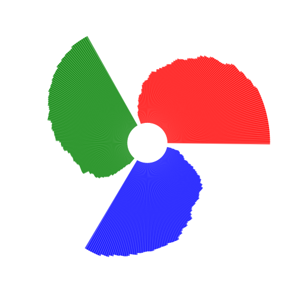

```python
import numpy as np
df_avg = get_avg(df_flags)
lObjectsALLcnts = df_flags["r"].sort_values(ascending=False)
lObjectsALLlbls = df_flags.index
iN = len(lObjectsALLcnts)
arrCnts = np.array(lObjectsALLcnts)

theta=np.arange(0,2*np.pi/3,2*np.pi/(3*iN))
width = (2*np.pi)/iN *0.5

fig = plt.figure(figsize=(8, 8))
ax = fig.add_axes([0.1, 0.1, 0.75, 0.75], polar=True)
bars = ax.bar(theta, arrCnts, width=width, bottom=50, color="r", alpha=0.7)



lObjectsALLcnts = df_flags["g"].sort_values(ascending=False)
lObjectsALLlbls = df_flags.index
iN = len(lObjectsALLcnts)
arrCnts = np.array(lObjectsALLcnts)

theta=np.arange(2*np.pi/3,4*np.pi/3,2*np.pi/(3*iN))
width = (2*np.pi)/iN *0.5

bars = ax.bar(theta, arrCnts, width=width, bottom=50, color="g", alpha=0.7)


lObjectsALLcnts = df_flags["b"].sort_values(ascending=False)
lObjectsALLlbls = df_flags.index
iN = len(lObjectsALLcnts)
arrCnts = np.array(lObjectsALLcnts)
theta=np.arange(4*np.pi/3,2*np.pi,2*np.pi/(3*iN))
theta = theta[:-1]
width = (2*np.pi)/iN *0.5


bars = ax.bar(theta, arrCnts, width=width, bottom=50, color="b", alpha=0.7)
plt.axis('off')
plt.savefig('rgb_dist.png',  bbox_inches='tight')
```

Para este gráfico primero se creó el dataframe con el número de colores por cada continente haciendo un groupby por continente como se explica a continuación en los comentarios.

```python
df_country_continent = pd.read_csv("country_continent.csv", keep_default_na=False) # df con codigos y continentes
df_country_continent = df_country_continent.set_index("iso 3166 country")
df_country_continent = df_country_continent.squeeze()
# Se juntan ambos df para que quede el codigo junto con el numero de colores de su bandera y con el continente al que pertenece
country_continent_number_colors = pd.concat([number_of_colors, df_country_continent], axis=1).dropna()
# Se hace un group by con el promedio para ver el promedio de colores por continente
continent_colors = pd.groupby(country_continent_number_colors, by="continent code").mean()
continent_colors.columns=["colors"]
display(continent_colors)
display(country_continent_number_colors[country_continent_number_colors["continent code"]=="AN"])
```

| continent code | colors |
| --- | --- |
| AF | 4.263158 |
| AN | 6.000000 |
| AS | 4.339623 |
| EU | 3.557692 |
| NA | 4.684211 |
| OC | 5.480000 |
| SA | 3.928571 |

|  | 0 | continent code |
| --- | --- | --- |
| AQ | 4.0 | AN |
| BV | 9.0 | AN |
| GS | 9.0 | AN |
| HM | 5.0 | AN |
| TF | 3.0 | AN |

### Grafica

Para el gráfico se utilizó un gráfico de Radar.

```
array(['AF', 'AN', 'AS', 'EU', 'NA', 'OC', 'SA'], dtype=object)
```

```
array([4.26315789, 6.        , 4.33962264, 3.55769231, 4.68421053,
       5.48      , 3.92857143, 4.26315789])
```

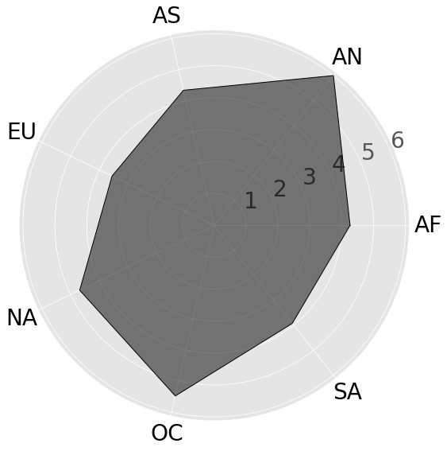

```python
from math import pi

# Se crean las listas de categorias y valores
categories=continent_colors.index.values
N = len(categories)
display(categories)
values=continent_colors["colors"].values
values = np.append(values, values[0]) # Para cerrar el radar
display(values)

# los lugares donde va cada marcador
angles = [n / float(N) * 2 * pi for n in range(N)]
angles += angles[:1]



fig = plt.figure(figsize=(8, 8))
ax = fig.add_subplot(111, projection='polar')

plt.xticks(angles[:-1], categories, color='black', size=28)



ax.plot(angles, values, linewidth=1, linestyle='solid', color="k")
ax.tick_params(axis='both', which='major', labelsize=28, pad=13, color="k")



ax.fill(angles, values, 'k', alpha=0.5)

plt.tight_layout()
plt.savefig('continent_ncolors.png',  bbox_inches='tight')
```

### Creacion de valores para gráfico de Radar en JS

Este ultimo código es para generar los valores que irán en el gráfico dinámico de Radar en JavaScript. Simplemente se utilizó cada columna de r, g y b con su codigo de continente y se aplico el groupby para tener el promedio de r, g y b para cada continente.

```python
country_continent_rgb = df_avg.join(df_country_continent)
r_continent = pd.groupby(country_continent_rgb.loc[:,["r", "continent code"]], by="continent code").mean()
g_continent = pd.groupby(country_continent_rgb.loc[:,["g", "continent code"]], by="continent code").mean()
b_continent = pd.groupby(country_continent_rgb.loc[:,["b", "continent code"]], by="continent code").mean()

lista_r = [item for sublist in r_continent.values.tolist() for item in sublist]
lista_g = [item for sublist in g_continent.values.tolist() for item in sublist]
lista_b = [item for sublist in b_continent.values.tolist() for item in sublist]
display(lista_r)
display(lista_g)
display(lista_b)
```

```
[131.04399717514121,
 98.36808333333335,
 161.63147988505744,
 176.70326923076925,
 128.17267094017095,
 114.58741666666667,
 150.55208333333337]
```

```
[116.27050847457629,
 76.14641666666667,
 110.25350574712644,
 106.54996794871798,
 108.70940170940172,
 97.50821666666667,
 119.06921875]
```

```
[91.24826977401125,
 138.22491666666667,
 101.3025287356322,
 110.64713141025638,
 125.08934829059832,
 118.5187,
 93.2134375]
```